# **GROUP 10 - COCA COLA STOCKS DATASET**

# Introduction

In this notebook you will implement the regression algorithm: Linear Regression:

- Dataset description: This dataset contains information about Coca Cola company stocks from 2012 to 2022

### Below is a list of sections.

- 1. Data Pre-Processing
- 2. Building the model
- 3. Make prediction

Now, let us begin!

```python
import pandas as pd
import numpy as np
import matplotlib.pyplot as plt
import seaborn as sns
```

```python
df = pd.read_csv("C:/Users/maymo/Downloads/Coca-Cola_Group15.csv")
df.head()
```

|  | Date | Open | High | Low | Close | Volume | Dividends | Stock Splits |
| --- | --- | --- | --- | --- | --- | --- | --- | --- |
| 0 | 2012-01-03 | 35.08 | 35.35 | 35.05 | 35.07 | 15639600 | 0.0 | 0 |
| 1 | 2012-01-04 | 34.95 | 35.03 | 34.75 | 34.85 | 14239200 | 0.0 | 0 |
| 2 | 2012-01-05 | 34.88 | 34.93 | 34.67 | 34.69 | 14287600 | 0.0 | 0 |
| 3 | 2012-01-06 | 34.73 | 34.81 | 34.31 | 34.47 | 13646600 | 0.0 | 0 |
| 4 | 2012-01-09 | 34.50 | 34.59 | 34.40 | 34.47 | 10522600 | 0.0 | 0 |

## 1. Data Pre-Processing

- We will check the data types for data cleaning purposes.

```python
df.info()
```

```
<class 'pandas.core.frame.DataFrame'>
RangeIndex: 2768 entries, 0 to 2767
Data columns (total 8 columns):
 #   Column        Non-Null Count  Dtype
---  ------        --------------  -----
 0   Date          2768 non-null   object
 1   Open          2768 non-null   float64
 2   High          2768 non-null   float64
 3   Low           2768 non-null   float64
 4   Close         2768 non-null   float64
 5   Volume        2768 non-null   int64
 6   Dividends     2768 non-null   float64
 7   Stock Splits  2768 non-null   int64
dtypes: float64(5), int64(2), object(1)
memory usage: 173.1+ KB
```

```python
df.describe()
```

|  | Open | High | Low | Close | Volume | Dividends | Stock Splits |
| --- | --- | --- | --- | --- | --- | --- | --- |
| count | 2768.000000 | 2768.000000 | 2768.000000 | 2768.000000 | 2.768000e+03 | 2768.000000 | 2768.000000 |
| mean | 46.240986 | 46.550983 | 45.925972 | 46.244491 | 1.439106e+07 | 0.005549 | 0.000723 |
| std | 7.337608 | 7.415198 | 7.255777 | 7.340632 | 6.255951e+06 | 0.044749 | 0.038014 |
| min | 33.650000 | 33.720000 | 33.280000 | 33.490000 | 2.996300e+06 | 0.000000 | 0.000000 |
| 25% | 40.857500 | 41.110000 | 40.630000 | 40.880000 | 1.050740e+07 | 0.000000 | 0.000000 |
| 50% | 44.495000 | 44.775000 | 44.150000 | 44.510000 | 1.307250e+07 | 0.000000 | 0.000000 |
| 75% | 50.990000 | 51.365000 | 50.472500 | 50.872500 | 1.650562e+07 | 0.000000 | 0.000000 |
| max | 67.000000 | 67.200000 | 65.720000 | 66.210000 | 9.896750e+07 | 0.440000 | 2.000000 |

```python
irrelevant_columns = ['Dividends', 'Stock Splits']
df = df.drop(columns=irrelevant_columns)
```

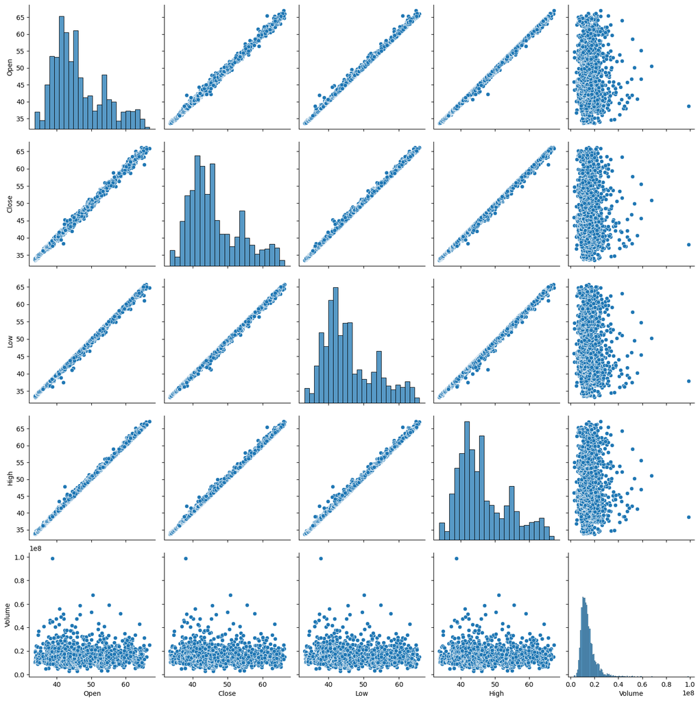

```python
df_plot = df[['Open', 'Close', 'Low', 'High','Volume']]
# Tạo pairplot
plt.figure()
sns.pairplot(df_plot, height=3, markers=["o", "s", "D"])
plt.show()
```

- In this dataset, we will choose the variable "Close" as the target variable with the purpose of predicting the closing price of coca cola company.
- Data points with constant volume (i.e., those along a horizontal line on the volume chart) likely have a weak connection to other factors. The chart we will be using is the second one on top
- We check the correlation between the two variables Open and Close

```python
Correlation = df['Open'].corr(df['Close'])
print(f'The correlation coefficient between "Open" and "Close" is: {Correlation}')
```

```
The correlation coefficient between "Open" and "Close" is: 0.998191824395903
```

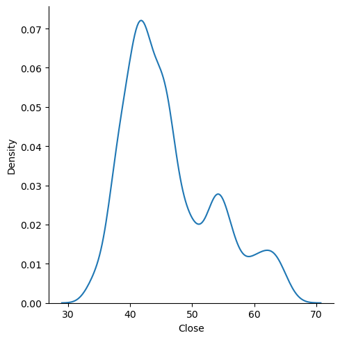

```python
sns.displot(df['Close'], kind = 'kde')
plt.show()
```

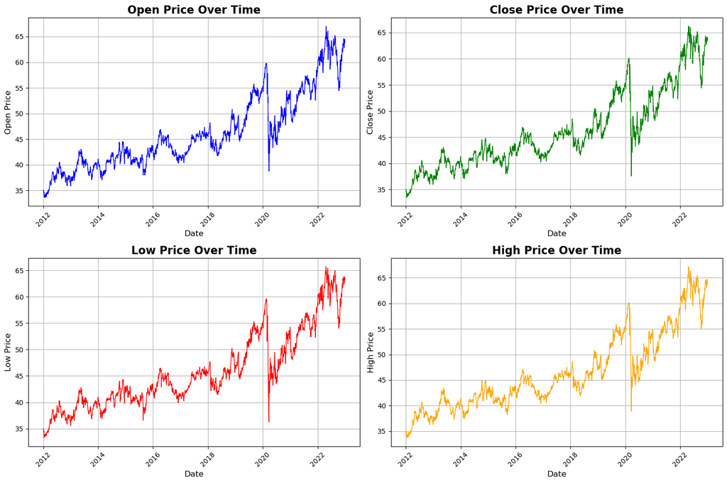

```python
plt.figure(figsize=(15, 10))
plt.subplots_adjust(top=1.25, bottom=1.2)

variables = ['Open', 'Close', 'Low', 'High']
colors = ['blue', 'green', 'red', 'orange']
for i, (variable, color) in enumerate(zip(variables, colors), 1):
    plt.subplot(2, 2, i)
    sns.lineplot(data=df, x='Date', y=variable, color=color, linewidth=1.0)
    plt.title(f'{variable} Price Over Time', fontsize=16, fontweight='bold')
    plt.xlabel('Date', fontsize=12)
    plt.ylabel(f'{variable} Price', fontsize=12)
    plt.grid(True)
    plt.xticks(rotation=45)

plt.tight_layout()
plt.show()
```

## 2. Building the model

- After preprocessing the data, we will proceed to build the model.

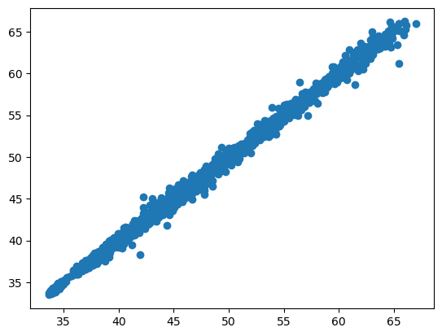

```python
x = df['Open']
y = df['Close']
plt.scatter(x,y)
plt.show()
```

```python
from sklearn.linear_model import LinearRegression
est = LinearRegression(fit_intercept=True)
x=df[['Open']]
y=df[['Close']]
est.fit(x,y)
print("The cofficient(s) a is(are)",est.coef_)
print("The intercept b is", est.intercept_)
```

```
The cofficient(s) a is(are) [[0.99860318]]
The intercept b is [0.06809476]
```

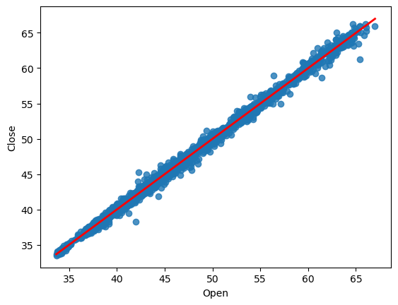

```python
x=df['Open']
y=df['Close']
sns.regplot(x=x, y=y, line_kws={'color': 'red', 'linewidth': 2}, label='Red Line')


equation = '$\\hat{y}$=' + str(est.coef_[0][0]) + 'x+' + str(est.intercept_[0])

plt.annotate(equation, xy=(4.5,2.8))

plt.show()
```

```python
from sklearn.model_selection import train_test_split
testperc=0.2
X_train, X_test, y_train, y_test = train_test_split(x, y, test_size = testperc, random_state = 42)
est = LinearRegression(fit_intercept=True)
est.fit(pd.DataFrame(X_train),pd.DataFrame(y_train))
print("The cofficient(s) a is(are)",est.coef_)
print("The intercept b is", est.intercept_)
```

```
The cofficient(s) a is(are) [[0.99874218]]
The intercept b is [0.054809]
```

## 3. Make Prediction

- After building the model, we will proceed to make prediction.

```python
y_test_pred=est.predict(pd.DataFrame(X_test))
y_test_pred
```

```
array([[45.31780443],
       [41.04318791],
       [48.05435799],
       [64.05420766],
       [38.31662177],
       [38.06693623],
       [39.63496145],
       [45.29782959],
       [45.87710005],
       [39.20550231],
       [47.39518816],
       [44.81843334],
       [43.39023203],
       [53.13795567],
       [46.44638309],
       [41.70235775],
       [45.8071881 ],
       [40.09438285],
       [40.40399292],
       [45.24789248],
       [46.00693653],
       [44.58872264],
       [45.04814404],
       [54.02683621],
       [48.68356556],
       [58.94064771],
       [46.38645856],
       [47.28532652],
       [40.98326338],
       [38.82598028],
       [60.22902512],
       [60.70842137],
       [57.18286148],
       [54.45629534],
       [46.36648371],
       [41.74230744],
       [40.00449605],
       [43.42019429],
       [54.23657206],
       [38.48640794],
```

[output cut: 499 more lines]

```
       [59.67971692],
       [47.70479823],
       [50.02188008],
       [39.57503692],
       [42.25166595],
       [39.40525075],
       [44.98821951],
       [54.37639597],
       [37.70738905],
       [62.84572962],
       [40.28414386],
       [57.91194327],
       [37.81725068],
       [40.06442058],
       [48.99317564]])
```

```python
y_train_pred=est.predict(pd.DataFrame(X_train))
y_train_pred
```

```
array([[46.20668497],
       [56.29398095],
       [53.23782989],
       ...,
       [44.51881069],
       [41.70235775],
       [40.4838923 ]])
```

```python
from sklearn.metrics import r2_score, mean_squared_error
R2_train = r2_score(y_train, y_train_pred)
R2_test = r2_score(y_test, y_test_pred)
MSE_train = mean_squared_error(y_train, y_train_pred)
MSE_test = mean_squared_error(y_test, y_test_pred)
```

```python
print('R2_train is:', R2_train)
print('R2_test is:', R2_test)
print('MSE_train is:', MSE_train)
print('MSE_test is:', MSE_test)
```

```
R2_train is: 0.9963111485528755
R2_test is: 0.9966582066837604
MSE_train is: 0.1948712018929935
MSE_test is: 0.19385699150272606
```

```python
y_test_pred=y_test_pred.ravel()
y_train_pred=y_train_pred.ravel()
```

```python
Residuals_train = y_train - y_train_pred
print(Residuals_train)
```

```
2124   -0.606685
2716    0.146019
2232    0.212170
261     0.072271
2059   -0.128962
          ...
1638   -0.138786
1095   -0.267289
1130    0.811189
1294    0.077642
860    -0.383892
Name: Close, Length: 2214, dtype: float64
```

```python
Residuals_test = y_test - y_test_pred
print(Residuals_test)
```

```
1378    0.112196
839    -0.383188
2164   -0.334358
2619   -0.674208
927     0.103378
          ...
874    -0.264144
2031    0.948057
100    -0.197251
315     0.795579
1740    1.406824
Name: Close, Length: 554, dtype: float64
```

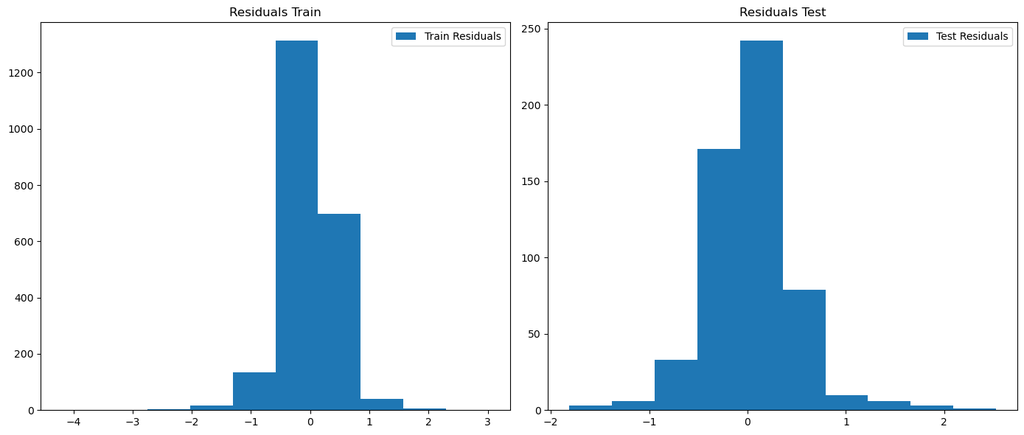

```python
#####
plt.figure(figsize=(14, 6))

plt.subplot(1, 2, 1)
plt.hist(Residuals_train, bins=10, label='Train Residuals')
plt.title("Residuals Train")
plt.tight_layout()
plt.legend()

plt.subplot(1, 2, 2)
plt.hist(Residuals_test, bins=10, label='Test Residuals')
plt.title("Residuals Test")
plt.tight_layout()
plt.legend()
```

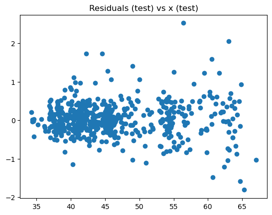

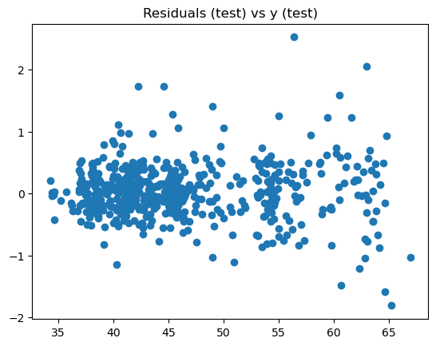

```python
plt.scatter(X_test, Residuals_test)
plt.title('Residuals (test) vs x (test)')
plt.show()
plt.scatter(y_test_pred, Residuals_test)
plt.title('Residuals (test) vs y (test)')
plt.show()
```

```python
from statsmodels.stats.stattools import durbin_watson
durbin_watson(Residuals_test)
```

```
1.9126791959757588
```

```python
import statsmodels.api as sm
X_train2 = sm.add_constant(X_train)
model = sm.OLS(y_train,X_train2)
results = model.fit()
results.summary()
```

OLS Regression Results

| Dep. Variable: | Close | R-squared: | 0.996 |
| --- | --- | --- | --- |
| Model: | OLS | Adj. R-squared: | 0.996 |
| Method: | Least Squares | F-statistic: | 5.974e+05 |
| Date: | Wed, 18 Dec 2024 | Prob (F-statistic): | 0.00 |
| Time: | 18:21:14 | Log-Likelihood: | -1331.1 |
| No. Observations: | 2214 | AIC: | 2666. |
| Df Residuals: | 2212 | BIC: | 2678. |
| Df Model: | 1 |  |  |
| Covariance Type: | nonrobust |  |  |

|  | coef | std err | t | P>\|t\| | [0.025 | 0.975] |
| --- | --- | --- | --- | --- | --- | --- |
| const | 0.0548 | 0.060 | 0.906 | 0.365 | -0.064 | 0.173 |
| Open | 0.9987 | 0.001 | 772.938 | 0.000 | 0.996 | 1.001 |

| Omnibus: | 616.469 | Durbin-Watson: | 1.918 |
| --- | --- | --- | --- |
| Prob(Omnibus): | 0.000 | Jarque-Bera (JB): | 9101.514 |
| Skew: | -0.900 | Prob(JB): | 0.00 |
| Kurtosis: | 12.768 | Cond. No. | 302. |

Notes:  
[1] Standard Errors assume that the covariance matrix of the errors is correctly specified.

```python
import statsmodels.api as sm
X_test2 = sm.add_constant(X_test)
model = sm.OLS(y_test,X_test2)
results = model.fit()
results.summary()
```

OLS Regression Results

| Dep. Variable: | Close | R-squared: | 0.997 |
| --- | --- | --- | --- |
| Model: | OLS | Adj. R-squared: | 0.997 |
| Method: | Least Squares | F-statistic: | 1.657e+05 |
| Date: | Wed, 18 Dec 2024 | Prob (F-statistic): | 0.00 |
| Time: | 18:21:16 | Log-Likelihood: | -329.92 |
| No. Observations: | 554 | AIC: | 663.8 |
| Df Residuals: | 552 | BIC: | 672.5 |
| Df Model: | 1 |  |  |
| Covariance Type: | nonrobust |  |  |

|  | coef | std err | t | P>\|t\| | [0.025 | 0.975] |
| --- | --- | --- | --- | --- | --- | --- |
| const | 0.1199 | 0.115 | 1.042 | 0.298 | -0.106 | 0.346 |
| Open | 0.9981 | 0.002 | 407.011 | 0.000 | 0.993 | 1.003 |

| Omnibus: | 84.554 | Durbin-Watson: | 1.925 |
| --- | --- | --- | --- |
| Prob(Omnibus): | 0.000 | Jarque-Bera (JB): | 444.849 |
| Skew: | 0.537 | Prob(JB): | 2.52e-97 |
| Kurtosis: | 7.256 | Cond. No. | 289. |

Notes:  
[1] Standard Errors assume that the covariance matrix of the errors is correctly specified.

## Congratulations

You have finished this notebook.